# SimmsFishFence

Eric V

17 February, 2025

# 1. Introduction

Simms Creek is a small, 3rd order stream that drains an area of ~1,800 ha into the Salish Sea, near Campbell River’s Willow Point neighborhood. The lower reach of Simms Creek (~3 km of channel, east of Jubilee Road), is contained within a narrow urban green way that is bordered by residential properties. From Jubilee Road to the Inland Highway the stream is protected within [Beaver Lodge Lands](https://campbellriver.travel/news/forestry-guide-to-beaver-lodge-lands/), upstream of the Inland Highway, >1.5 km of tributary channel is located within private forest lands.

Historic fish observations indicate that Chum, Chinook, Pink and Coho salmon have all been observed in the stream, as well as Coastal Cutthroat Trout (CCT), Rainbow Trout and steelhead. More recent monitoring (i.e., this dataset), suggest that Coho Salmon (CO) and CCT are the primary species within Simms Creek, both of which utilize the stream year round - though a small number of juvenile Chinook Salmon were identified in 2024.

[Greenways Land Trust](https://www.greenwaystrust.ca/) has supported Simms Creek Stewards for +20 years, including operation of a fish fence near the mouth of the stream since 2008. Juvenile and adult fish moving past the fence are tallied each spring and fall, respectively. The objective of this project is to explore the juvenile fence dataset. All work is being done strictly for fun and out of personal curiosity. Any feedback, input, or support is welcome. Also, I have a soft spot for CCT, so be warned that effort and results will be slightly trout biased.

Throughout this analysis, I explore what data collected during spring and fall can tell us about:

1. What species are utilizing Simms Creek?
2. Whether the current fence operation program is capturing the complete migration period?
3. When are key behaviours occurring (e.g., when is peak smolt? when do adults arrive?) and are they occurring at consistent times each year?
4. How large are fish encountered during smolt and upstream migration periods? What age classes are migrating (I don’t have scale data, but we can make an educated guess).
5. What is the freshwater survival of Coho Salmon? Note that we cannot estimate marine survival without some information on individual fish (i.e., coded wire tag data to verify that returning adults originated in Simms Creek and when they smolted).
6. What factors may be driving variability in the number of CCT and CO smolts outmigrating each spring and the number of adult CO returning each fall.

But before we can do that, lets take a look at what has been completed to date. It’s a tremendous amount of work and all volunteers and supporters should be commended!

# 2. Fence Operation

### 2.1. Monitoring Effort

The Simms Creek fish fence has operated annually since 2008, with the exception of 2020 and 2021 when operations were paused due to the COVID-19 Pandemic and in the spring of 2023 when federal employees were on strike.

Spring surveys target out migrating juvenile Coho Salmon but also capture an impressive number of CCT and have even captured some Chinook Salmon. Spring fence monitoring has started as early as April 03, however, most surveys (50%) don’t start until April 18. In each monitoring year, the fence has operated continuously (e.g., sampling occurred at least daily) from April 28 to May 30. Surveys have continued as late as June 13, but most (50%) are terminated by June 06.

#### Table 2. Annual Spring and Fall Trap Operation Periods

Table 2. Annual spring and fall trap operation periods.

| Year | Spring Sampling # Days Sampled | Spring Sampling Start | Spring Sampling End | Fall Sampling # Days Sampled | Fall Sampling Start | Fall Sampling End |
| --- | --- | --- | --- | --- | --- | --- |
| 2008 | 41 | Apr-21 | May-31 | 40 | Oct-14 | Nov-22 |
| 2009 | 50 | Apr-19 | Jun-07 | 40 | Oct-14 | Nov-22 |
| 2010 | 42 | Apr-19 | May-30 | 35 | Oct-23 | Nov-26 |
| 2011 | 49 | Apr-19 | Jun-06 | 46 | Oct-18 | Dec-02 |
| 2012 | 50 | Apr-16 | Jun-04 | 50 | Oct-14 | Dec-02 |
| 2013 | 49 | Apr-14 | Jun-01 | 62 | Sep-29 | Dec-01 |
| 2014 | 45 | Apr-24 | Jun-07 | 58 | Oct-04 | Nov-30 |
| 2015 | 52 | Apr-10 | May-31 | 62 | Oct-08 | Dec-08 |
| 2016 | 63 | Apr-03 | Jun-04 | 60 | Oct-07 | Dec-05 |
| 2017 | 68 | Apr-05 | Jun-11 | 56 | Oct-11 | Dec-05 |
| 2018 | 52 | Apr-21 | Jun-11 | 58 | Oct-08 | Dec-04 |
| 2019 | 51 | Apr-18 | Jun-07 | 64 | Oct-08 | Dec-10 |
| 2020 | 0 | COVID | - | 0 | - | - |
| 2021 | 0 | COVID | - | 0 | - | - |
| 2022 | 47 | Apr-28 | Jun-13 | 37 | Oct-11 | Nov-16 |
| 2023 | 0 | DFO Strike | - | 45 | Sep-26 | Nov-17 |
| 2024 | 55 | Apr-12 | Jun-05 | 0 | - | - |

### 2.2 Stream Conditions

#### Stream Conditions Figures and Tables

#### Table 3. Spring Condition Table

Table 3. Stream conditions during spring trap operation.

| Year | Spring Monitoring Air Temp. (°C) Mean | Spring Monitoring Air Temp. (°C) SD | Spring Monitoring Water Temp. (°C) Mean | Spring Monitoring Water Temp. (°C) SD | Spring Monitoring pH . Mean | Spring Monitoring pH . SD | Spring Monitoring DO (mg/L) Mean | Spring Monitoring DO (mg/L) SD | Spring Monitoring TDS (ppm) Mean | Spring Monitoring TDS (ppm) SD | Spring Monitoring Water Level (m) Mean | Spring Monitoring Water Level (m) SD |
| --- | --- | --- | --- | --- | --- | --- | --- | --- | --- | --- | --- | --- |
| 2008 | 9.5 | 4.0 | 10.5 | 2.8 | 7.1 | 0.3 | 10.8 | 0.8 | 67.8 | 36.8 | 0.2 | 0.0 |
| 2009 | 11.8 | 3.0 | 10.3 | 2.4 | 7.1 | 0.2 | 10.3 | 0.8 | 136.4 | 26.2 | 0.3 | 0.0 |
| 2010 | 9.5 | 2.2 | 10.0 | 1.6 | 8.2 | 0.3 | 10.5 | 1.8 | 110.2 | 17.4 | 0.2 | 0.1 |
| 2011 | 9.8 | 2.3 | 9.8 | 2.1 | 6.7 | 0.3 | 9.1 | 1.0 | 95.5 | 11.7 | 0.2 | 0.0 |
| 2012 | 11.0 | 2.1 | 10.2 | 1.7 | 7.4 | 0.8 | 9.9 | 1.4 | 99.4 | 17.2 | 0.2 | 0.1 |
| 2013 | 10.3 | 2.9 | 10.1 | 2.0 | 7.9 | 0.3 | 11.5 | 0.9 | 100.6 | 14.9 | 0.2 | 0.1 |
| 2014 | 12.2 | 2.4 | 11.3 | 1.7 | 8.1 | 0.5 | 9.7 | 0.6 | 97.8 | 19.2 | 0.2 | 0.1 |
| 2015 | 10.5 | 3.4 | 11.0 | 2.5 | 8.1 | 0.2 | 9.4 | 0.8 | 106.7 | 22.2 | 0.2 | 0.4 |
| 2016 | 11.4 | 2.8 | 11.7 | 1.8 | 7.1 | 0.4 | 10.2 | 1.5 | 111.3 | 20.1 | 0.1 | 0.0 |
| 2017 | 9.6 | 3.0 | 10.2 | 2.3 | 8.2 | 0.4 | 10.9 | 2.2 | 77.8 | 25.6 | 0.3 | 0.1 |
| 2018 | 10.7 | 2.5 | 8.7 | 1.3 | 8.8 | 1.4 | 14.2 | 1.6 | 153.9 | 21.2 | 0.1 | 0.0 |
| 2019 | 11.2 | 2.7 | 11.9 | 2.3 | 8.0 | 0.2 | 8.6 | 0.7 | 129.0 | 25.7 | 0.1 | 0.1 |
| 2022 | 11.7 | 2.5 | 12.2 | 16.0 | 7.5 | 0.3 | - | - | 83.0 | 17.2 | 0.2 | 0.1 |
| 2023 | - | - | - | - | - | - | - | - | - | - | - | - |
| 2024 | 12.1 | 2.2 | 10.3 | 2.1 | 7.7 | 0.4 | 10.2 | 0.9 | 129.8 | 30.0 | 0.1 | 0.0 |

#### Table 4. Fall Condition Table

Table 4. Stream conditions during fall trap operation.

| Year | Fall Monitoring Air Temp. (°C) Mean | Fall Monitoring Air Temp. (°C) SD | Fall Monitoring Water Temp. (°C) Mean | Fall Monitoring Water Temp. (°C) SD | Fall Monitoring pH . Mean | Fall Monitoring pH . SD | Fall Monitoring DO (mg/L) Mean | Fall Monitoring DO (mg/L) SD | Fall Monitoring TDS (ppm) Mean | Fall Monitoring TDS (ppm) SD | Fall Monitoring Water Level (m) Mean | Fall Monitoring Water Level (m) SD |
| --- | --- | --- | --- | --- | --- | --- | --- | --- | --- | --- | --- | --- |
| 2008 | 6.3 | 3.0 | 8.8 | 1.3 | 7.3 | 0.4 | 10.5 | 0.4 | 120.2 | 30.9 | 0.4 | 0.1 |
| 2009 | 6.8 | 3.3 | 8.7 | 1.9 | 7.6 | 0.2 | 10.6 | 1.9 | 105.0 | 28.7 | 0.5 | 0.2 |
| 2010 | 4.9 | 4.7 | 7.9 | 2.7 | 7.0 | 0.2 | 9.5 | 0.9 | 110.9 | 31.1 | 0.6 | 0.9 |
| 2011 | 4.9 | 3.0 | 7.0 | 1.8 | 7.3 | 0.6 | 9.7 | 0.5 | 112.7 | 30.1 | 0.3 | 0.3 |
| 2012 | 5.9 | 3.2 | 7.8 | 1.7 | 7.5 | 0.2 | 10.8 | 1.6 | 116.1 | 29.6 | 0.4 | 0.2 |
| 2013 | 6.1 | 3.1 | 8.0 | 2.0 | 7.7 | 0.1 | 10.5 | 0.7 | 119.8 | 30.6 | 0.3 | 0.1 |
| 2014 | 7.3 | 5.0 | 9.6 | 3.2 | 7.9 | 0.2 | 10.0 | 1.2 | 85.3 | 29.8 | 0.3 | 0.1 |
| 2015 | 6.0 | 4.3 | 8.5 | 3.0 | 8.2 | 0.2 | 10.2 | 2.1 | 97.1 | 29.5 | 0.3 | 0.2 |
| 2016 | 7.8 | 3.1 | 9.3 | 1.8 | 8.1 | 1.3 | 9.3 | 1.3 | 54.0 | 9.2 | 0.5 | 0.2 |
| 2017 | 4.8 | 3.3 | 8.4 | 1.9 | 8.1 | 0.7 | 12.8 | 1.4 | 101.8 | 38.2 | 0.3 | 0.2 |
| 2018 | 6.4 | 3.5 | 9.2 | 1.9 | 7.9 | 0.3 | 10.4 | 0.6 | 88.8 | 29.0 | 0.3 | 0.1 |
| 2019 | 5.2 | 3.8 | 8.2 | 2.3 | 7.6 | 0.1 | 11.5 | 1.0 | 103.9 | 26.6 | 0.2 | 0.1 |
| 2022 | 6.9 | 4.9 | 8.4 | 2.5 | 7.8 | 0.2 | 10.1 | - | 126.9 | 83.3 | 0.2 | 0.6 |
| 2023 | 8.3 | 5.4 | 9.6 | 2.4 | 7.8 | 0.2 | 10.7 | 0.7 | 66.4 | 66.1 | 0.2 | 0.1 |
| 2024 | - | - | - | - | - | - | - | - | - | - | - | - |

#### Figure 2. Spring and Fall Condition Plot

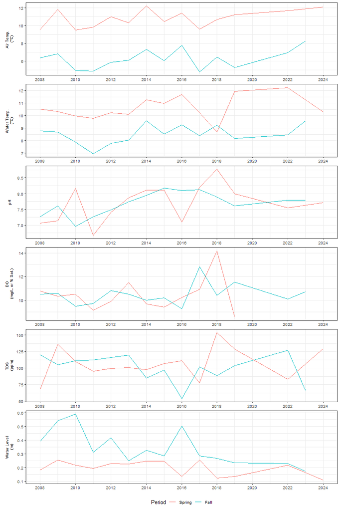

### 2.3. Annual Captures

Since 2008, a total of 5,046 juvenile CCT and 8,216 juvenile Coho Salmon have been captured during spring trapping. Annual captures of CCT have ranged from 45 to 849 (mean = 360) while CO captures have varied from 335 to 913 with an overall mean of 587 fish (Figure 3 and Figure 4, Table 5 and Table 6).

#### Annual Captures Figures and Tables

#### Figure 3. Spring - Total annual catches

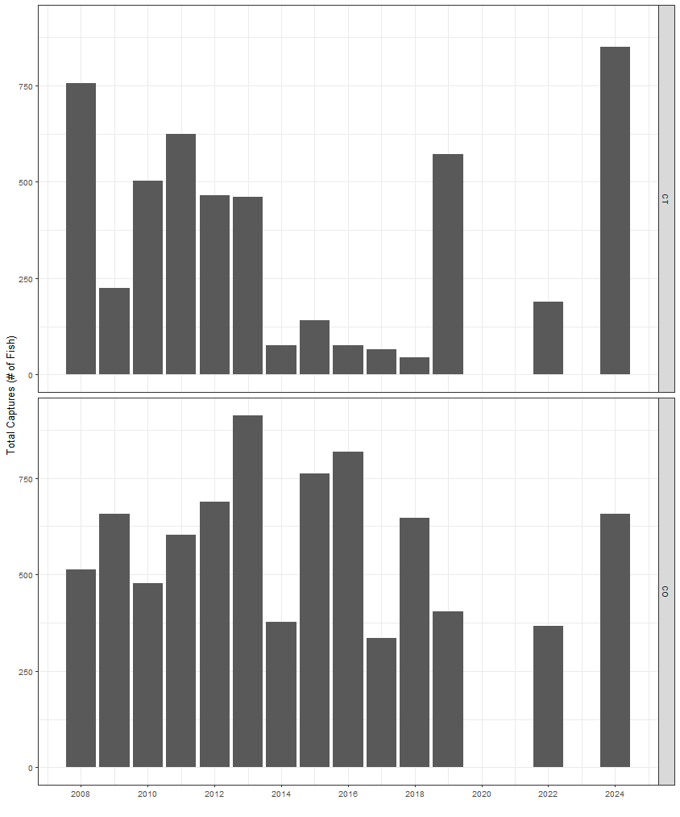

#### Table 5. Spring - Total annual catches

**Table 5. Spring capture summary - capture timing, total captures and length of CCT and Coho Salmon.**

| Year | Sample Period Start | Sample Period End | Sample Period # Days Sampled | CCT Capture Timing Med. | CCT Capture Timing Min | CCT Capture Timing Max | CCT Fork Length (mm) n | CCT Fork Length (mm) Mean | CCT Fork Length (mm) SD | CCT Fork Length (mm) Min | CCT Fork Length (mm) Max | Coho Salmon Capture Timing Med. | Coho Salmon Capture Timing Min | Coho Salmon Capture Timing Max | Coho Salmon Fork Length (mm) n | Coho Salmon Fork Length (mm) Mean | Coho Salmon Fork Length (mm) SD | Coho Salmon Fork Length (mm) Min | Coho Salmon Fork Length (mm) Max |
| --- | --- | --- | --- | --- | --- | --- | --- | --- | --- | --- | --- | --- | --- | --- | --- | --- | --- | --- | --- |
| 2008 | Apr-21 | May-31 | 41 | May-20 | Apr-21 | May-31 | 756 | 139.1 | 27.6 | 90 | 280 | May-17 | Apr-25 | May-31 | 512 | 118.1 | 10.7 | 84.0 | 150 |
| 2009 | Apr-19 | Jun-07 | 50 | May-16 | Apr-20 | Jun-03 | 225 | 163.3 | 22.9 | 115 | 265 | May-20 | Apr-24 | Jun-07 | 658 | 100.2 | 11.0 | 11.0 | 160 |
| 2010 | Apr-19 | May-30 | 42 | May-13 | Apr-19 | May-29 | 502 | 149.7 | 26.1 | 110 | 285 | May-13 | Apr-20 | May-30 | 477 | 118.0 | 15.7 | 80.0 | 183 |
| 2011 | Apr-19 | Jun-06 | 49 | May-15 | Apr-23 | Jun-05 | 624 | 155.3 | 32.5 | 95 | 400 | May-17 | Apr-20 | Jun-06 | 602 | 113.1 | 12.8 | 80.0 | 147 |
| 2012 | Apr-16 | Jun-04 | 50 | May-08 | Apr-23 | Jun-01 | 465 | 160.1 | 33.7 | 80 | 335 | May-13 | Apr-16 | Jun-04 | 689 | 107.8 | 12.4 | 75.0 | 145 |
| 2013 | Apr-14 | Jun-01 | 49 | May-09 | Apr-16 | May-30 | 461 | 161.4 | 26.5 | 95 | 350 | May-12 | Apr-15 | Jun-01 | 913 | 106.7 | 9.9 | 83.0 | 150 |
| 2014 | Apr-24 | Jun-07 | 45 | May-09 | Apr-27 | Jun-02 | 76 | 142.1 | 29.2 | 70 | 310 | May-12 | Apr-26 | Jun-05 | 376 | 103.2 | 12.4 | 80.0 | 223 |
| 2015 | Apr-10 | May-31 | 52 | May-09 | Apr-15 | May-28 | 141 | 158.1 | 37.4 | 85 | 260 | May-13 | Apr-11 | May-31 | 761 | 109.3 | 11.7 | 78.0 | 152 |
| 2016 | Apr-03 | Jun-04 | 63 | Apr-26 | Apr-05 | May-15 | 77 | 147.5 | 37.4 | 88 | 250 | May-05 | Apr-05 | Jun-04 | 817 | 108.0 | 13.4 | 0.0 | 162 |
| 2017 | Apr-05 | Jun-11 | 68 | May-24 | Apr-20 | Jun-09 | 65 | 185.1 | 64.0 | 120 | 470 | May-20 | Apr-05 | Jun-11 | 335 | 113.4 | 12.8 | 80.0 | 162 |
| 2018 | Apr-21 | Jun-11 | 52 | May-04 | Apr-26 | May-27 | 45 | 167.4 | 28.2 | 120 | 230 | May-19 | Apr-21 | Jun-11 | 647 | 101.4 | 11.1 | 9.0 | 170 |
| 2019 | Apr-18 | Jun-07 | 51 | May-06 | Apr-18 | May-30 | 571 | 146.1 | 27.6 | 95 | 260 | May-13 | Apr-24 | Jun-05 | 405 | 115.4 | 12.9 | 10.7 | 152 |
| 2022 | Apr-28 | Jun-13 | 47 | May-19 | Apr-29 | Jun-13 | 189 | 168.5 | 33.6 | 98 | 430 | May-21 | Apr-28 | Jun-10 | 366 | 113.7 | 13.0 | 80.0 | 170 |
| 2024 | Apr-12 | Jun-05 | 55 | Apr-29 | Apr-17 | Jun-03 | 849 | 159.8 | 37.1 | 50 | 360 | May-10 | Apr-18 | Jun-04 | 658 | 97.5 | 17.6 | 48.0 | 174 |

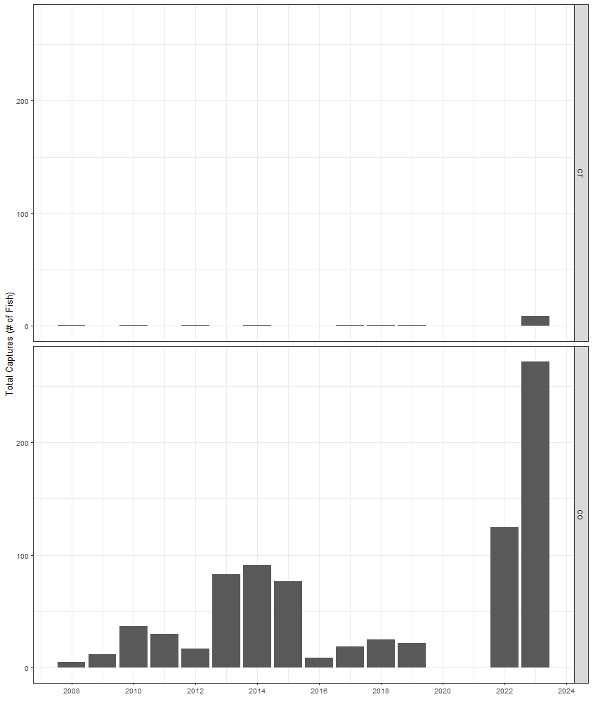

#### Table 6. Fall - Total annual catches

**Table 6. Fall capture summary - capture timing, total captures and length of CCT and Coho Salmon.**

| Year | Sample Period Start | Sample Period End | Sample Period # Days Sampled | CCT Capture Timing Med. | CCT Capture Timing Min | CCT Capture Timing Max | CCT Fork Length (mm) n | CCT Fork Length (mm) Mean | CCT Fork Length (mm) SD | CCT Fork Length (mm) Min | CCT Fork Length (mm) Max | Coho Salmon Capture Timing Med. | Coho Salmon Capture Timing Min | Coho Salmon Capture Timing Max | Coho Salmon Fork Length (mm) n | Coho Salmon Fork Length (mm) Mean | Coho Salmon Fork Length (mm) SD | Coho Salmon Fork Length (mm) Min | Coho Salmon Fork Length (mm) Max |
| --- | --- | --- | --- | --- | --- | --- | --- | --- | --- | --- | --- | --- | --- | --- | --- | --- | --- | --- | --- |
| 2008 | Oct-14 | Nov-22 | 40 | Nov-03 | Nov-03 | Nov-03 | 1 | 440.0 | - | 440 | 440 | Nov-02 | Oct-31 | Nov-03 | 5 | 638.0 | 78.9 | 540 | 720 |
| 2009 | Oct-14 | Nov-22 | 40 | - | - | - | 0 | - | - | - | - | Nov-03 | Oct-17 | Nov-18 | 12 | 648.3 | 84.1 | 490 | 790 |
| 2010 | Oct-23 | Nov-26 | 35 | Nov-11 | Nov-11 | Nov-11 | 1 | 290.0 | - | 290 | 290 | Oct-25 | Oct-24 | Nov-22 | 37 | 640.1 | 91.5 | 405 | 780 |
| 2011 | Oct-18 | Dec-02 | 46 | - | - | - | 0 | - | - | - | - | Nov-12 | Oct-26 | Nov-23 | 30 | 650.5 | 82.9 | 370 | 795 |
| 2012 | Oct-14 | Dec-02 | 50 | Oct-28 | Oct-28 | Oct-28 | 1 | 580.0 | - | 580 | 580 | Nov-01 | Oct-14 | Nov-20 | 17 | 583.2 | 107.1 | 300 | 690 |
| 2013 | Sep-29 | Dec-01 | 62 | - | - | - | 0 | - | - | - | - | Nov-06 | Nov-02 | Nov-18 | 83 | 631.7 | 59.7 | 490 | 790 |
| 2014 | Oct-04 | Nov-30 | 58 | Oct-28 | Oct-28 | Oct-28 | 1 | 430.0 | - | 430 | 430 | Oct-28 | Oct-15 | Nov-27 | 91 | 627.8 | 87.8 | 330 | 830 |
| 2015 | Oct-08 | Dec-08 | 62 | - | - | - | 0 | - | - | - | - | Nov-08 | Oct-12 | Dec-02 | 77 | 600.0 | 89.4 | 350 | 750 |
| 2016 | Oct-07 | Dec-05 | 60 | - | - | - | 0 | - | - | - | - | Nov-01 | Oct-24 | Nov-17 | 9 | 632.8 | 77.9 | 510 | 750 |
| 2017 | Oct-11 | Dec-05 | 56 | Nov-19 | Nov-19 | Nov-19 | 1 | 470.0 | - | 470 | 470 | Nov-15 | Oct-18 | Dec-04 | 19 | 592.4 | 133.3 | 330 | 770 |
| 2018 | Oct-08 | Dec-04 | 58 | Nov-01 | Nov-01 | Nov-01 | 1 | 330.0 | - | 330 | 330 | Nov-14 | Oct-26 | Nov-28 | 25 | 605.5 | 91.0 | 380 | 790 |
| 2019 | Oct-08 | Dec-10 | 64 | Oct-16 | Oct-16 | Oct-16 | 1 | 390.0 | - | 390 | 390 | Oct-25 | Oct-16 | Nov-17 | 22 | 566.8 | 110.2 | 340 | 710 |
| 2022 | Oct-11 | Nov-16 | 37 | - | - | - | 0 | - | - | - | - | Nov-03 | Oct-24 | Nov-06 | 125 | 612.7 | 97.5 | 220 | 750 |
| 2023 | Sep-26 | Nov-17 | 45 | Nov-02 | Nov-02 | Nov-16 | 9 | 239.1 | 108.9 | 152 | 430 | Oct-18 | Oct-11 | Nov-16 | 272 | 571.3 | 96.5 | 220 | 740 |

### 2.4. Migration Timing

**2.4.1 Spring Outmigration**

**2.4.2 Fall Return Timing**

#### Spring and Fall Migration Timing Tables and Figures

#### Figure 5. Spring - Overall Capture Timing

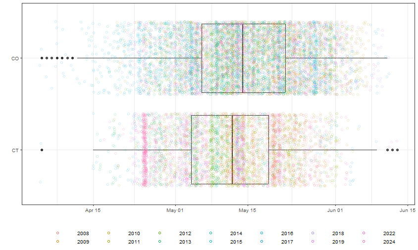

#### Figure 5. Spring - Median CO Capture Timing Across Years

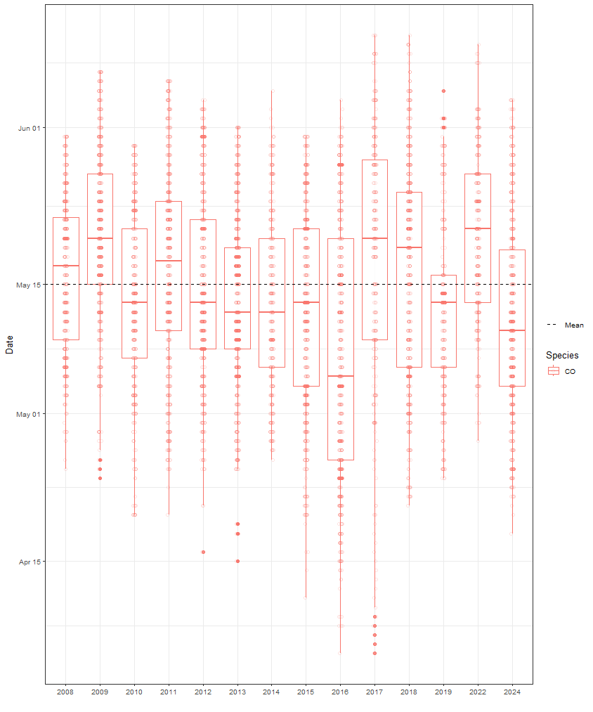

[figure not shown]

#### Figure 7. Spring - Frequency of Peak CCT Migration

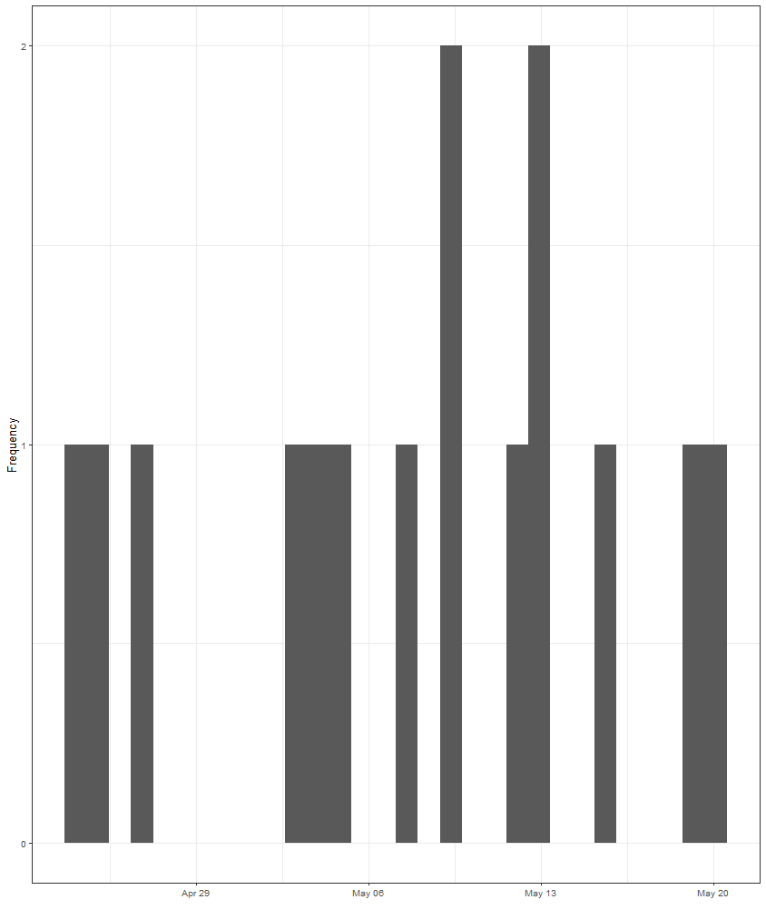

#### Figure 8. Spring - Daily captures of CCT per year

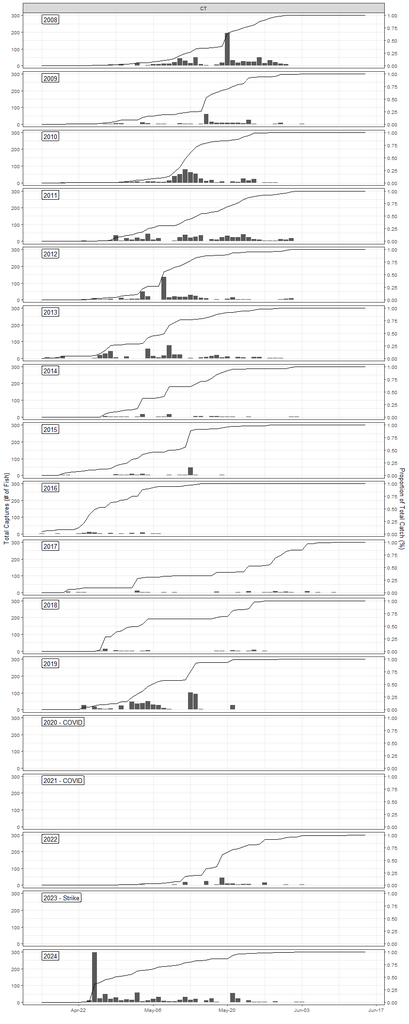

#### Figure 10. Spring - Total daily captures of CCT across years

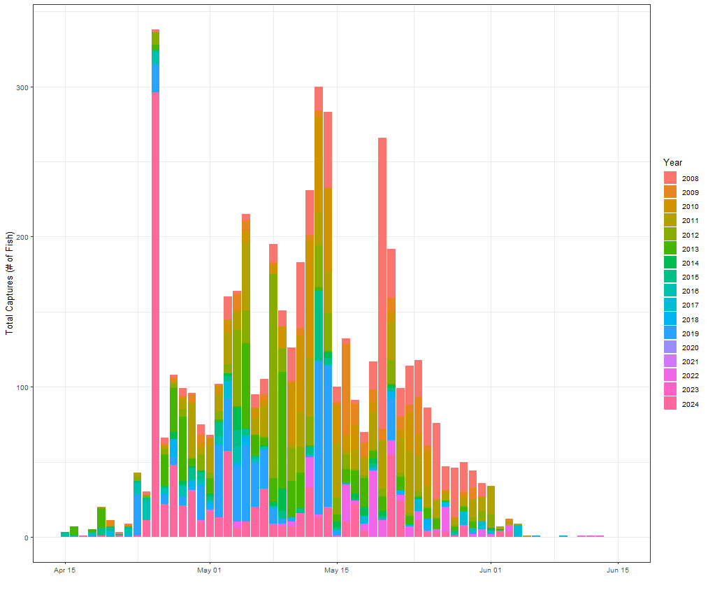

#### Figure 11. Spring - Frequency of Peak Coho Migration

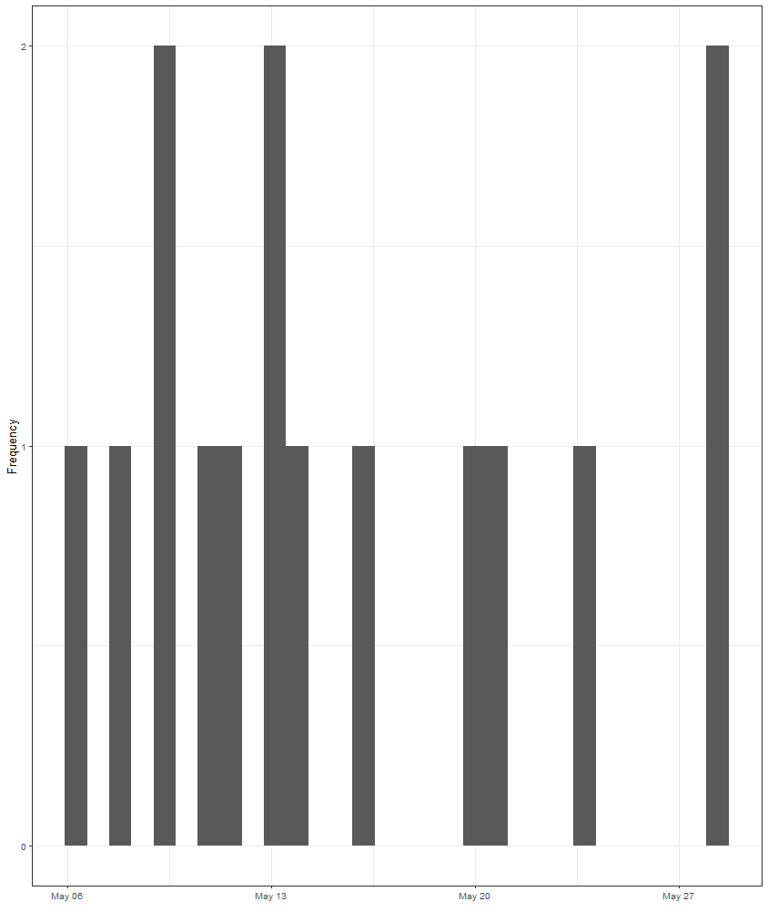

#### Figure 12. Spring - Total daily captures of Coho Salmon per year

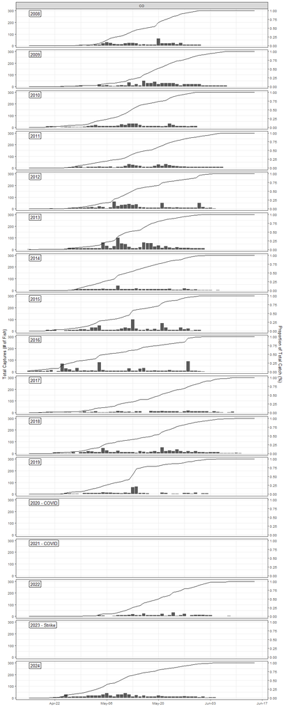

#### Figure 13. Spring - Total daily captures of Coho across years

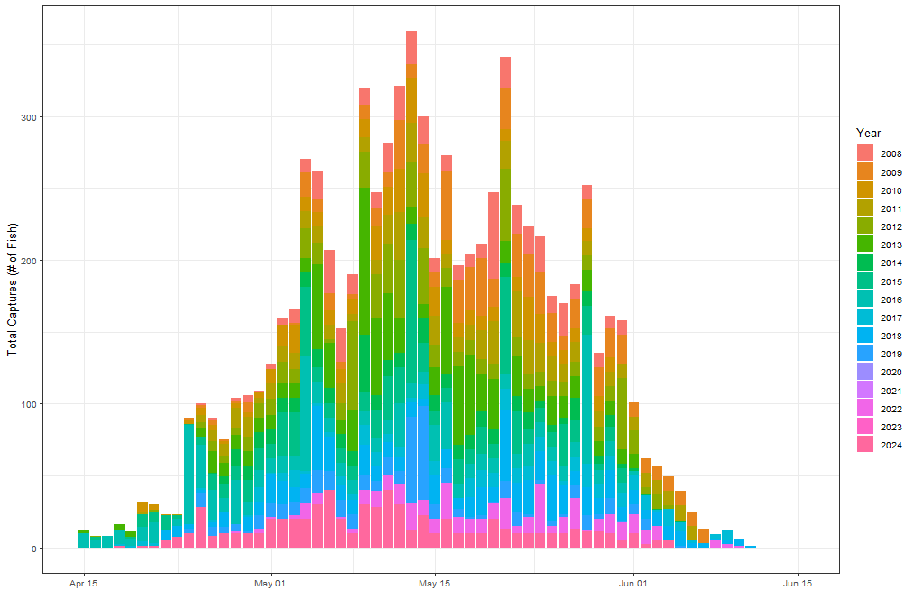

#### Figure 14. Fall - Overall Capture Timing

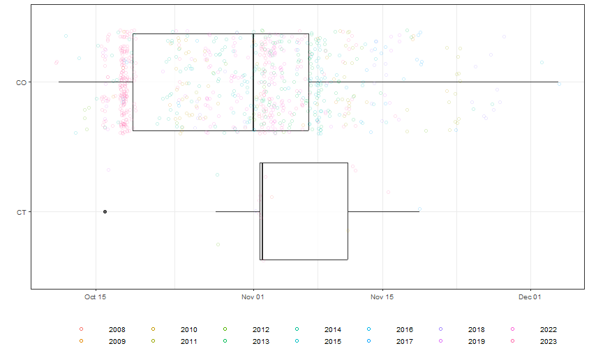

#### Figure 15. Fall - Median Fall CO Capture Timing Across Years

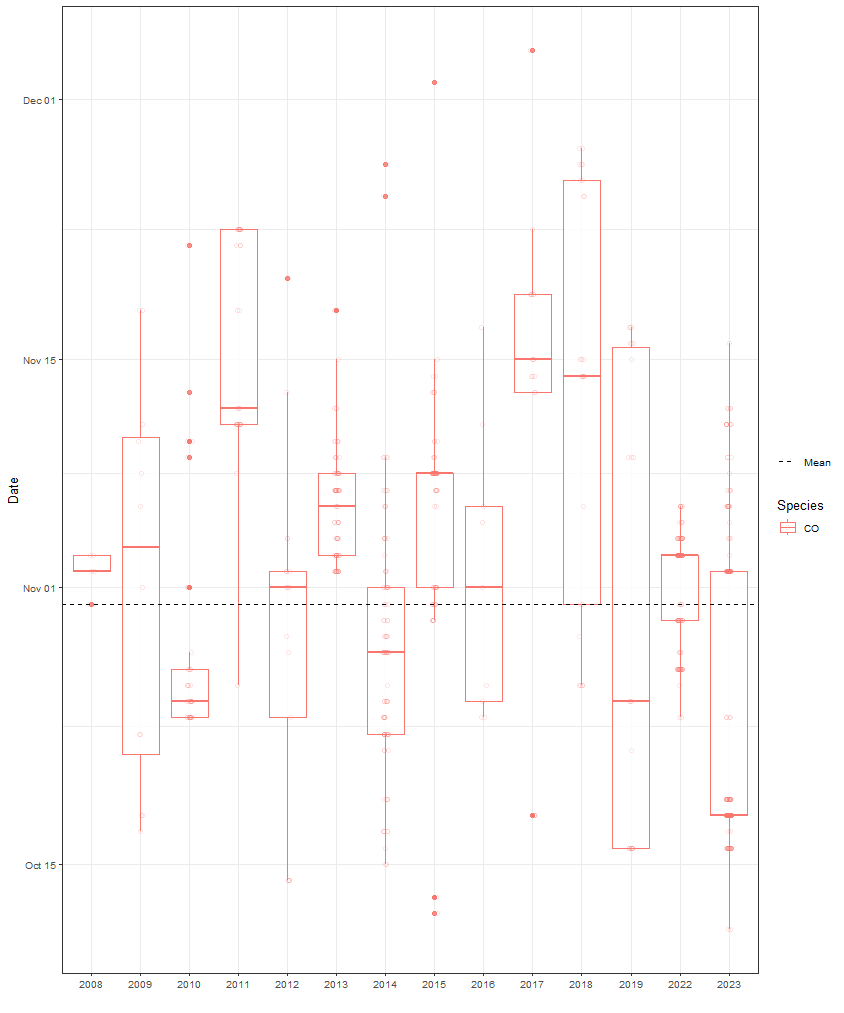

[figure not shown]

#### Figure 17. Fall - Frequency of Peak Coho Migration

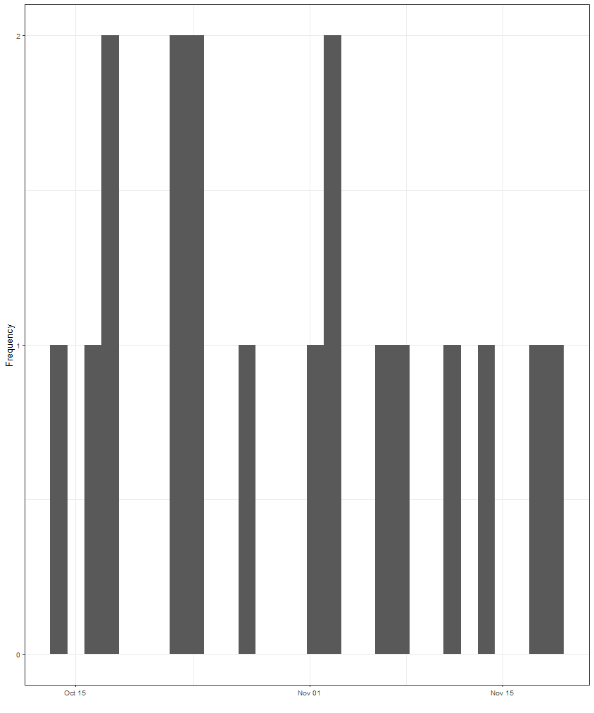

#### Figure 18. Fall - Total daily captures of Coho Salmon per year

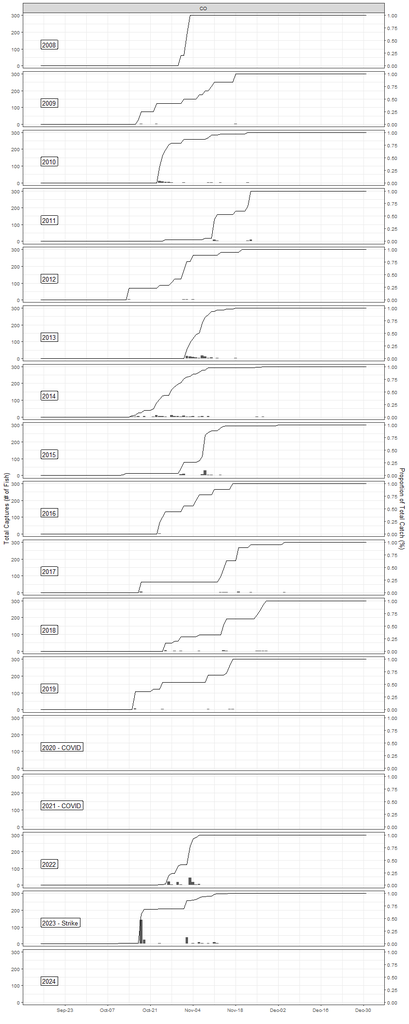

#### Figure 19. Fall - Total daily captures of Coho across years

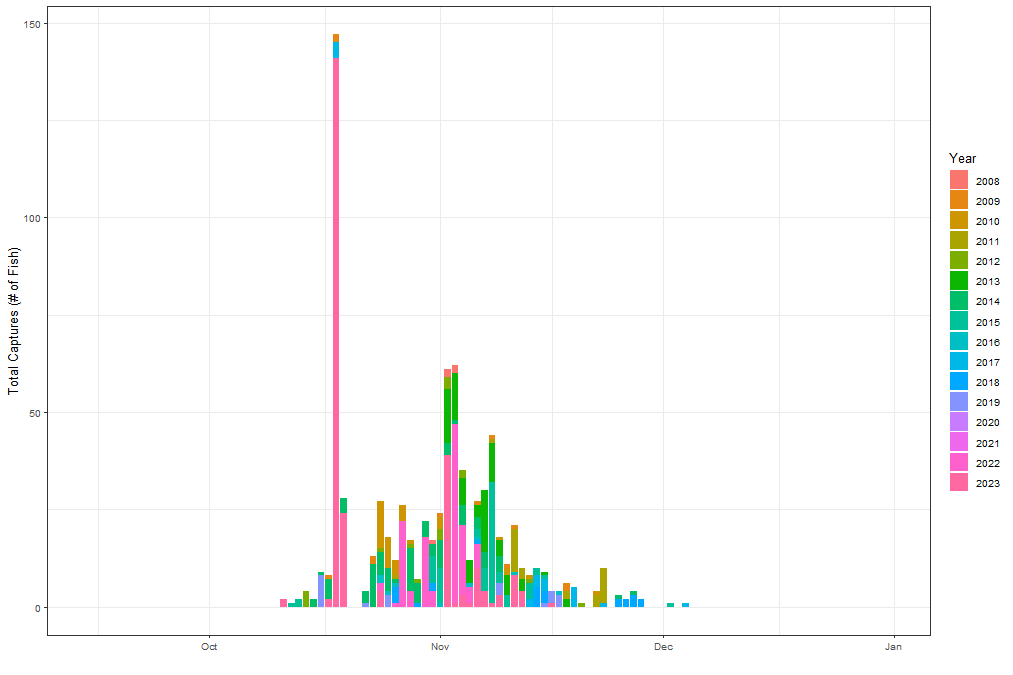

#### Figure 20. Fall - Daily captures of CCT per year

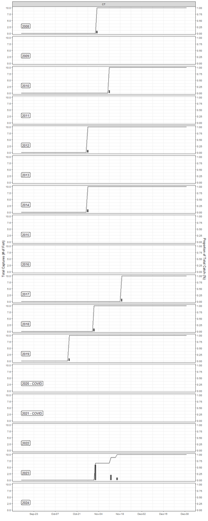